# HW4 - Jingwen Li

## Week 4 HW: Advanced Arima modeling

### Jingwen Li

```python
import matplotlib.pyplot as plt
from datetime import datetime
import pandas as pd
from statsmodels.tsa.stattools import adfuller, kpss
from sktime.forecasting.model_selection import temporal_train_test_split
from sktime.forecasting.arima import ARIMA, AutoARIMA
from sktime.forecasting.base import ForecastingHorizon
from sktime.performance_metrics.forecasting import MeanAbsolutePercentageError, MeanAbsoluteScaledError
from sklearn.metrics import mean_absolute_error, mean_squared_error
from statsmodels.graphics.tsaplots import plot_acf, plot_pacf
from statsmodels.tsa.statespace.sarimax import SARIMAX
from pmdarima.arima import auto_arima
from statsmodels.stats.diagnostic import acorr_ljungbox
import warnings
warnings.filterwarnings("ignore")
```

## Part 1. Exploratory Data Analysis

### 1.1 Complete a quantitative and qualitative data exploration. Include a verbal summary of your EDA.

```python
y = pd.read_csv('hw4_data.csv', index_col=0, parse_dates=True)

y
```

| ds | co2 |
| --- | --- |
| 1958-03-15 | 315.700 |
| 1958-04-15 | 317.450 |
| 1958-05-15 | 317.510 |
| 1958-06-15 | 316.685 |
| 1958-07-15 | 315.860 |
| ... | ... |
| 2019-01-15 | 410.920 |
| 2019-02-15 | 411.660 |
| 2019-03-15 | 412.000 |
| 2019-04-15 | 413.510 |
| 2019-05-15 | 414.830 |

735 rows × 1 columns

```
Numerical
```

```python
y.describe()
```

|  | co2 |
| --- | --- |
| count | 735.000000 |
| mean | 354.210673 |
| std | 27.922811 |
| min | 313.200000 |
| 25% | 328.785000 |
| 50% | 351.340000 |
| 75% | 376.515000 |
| max | 414.830000 |

```python
y.isna().sum()
```

```
co2    0
dtype: int64
```

```
Visual
```

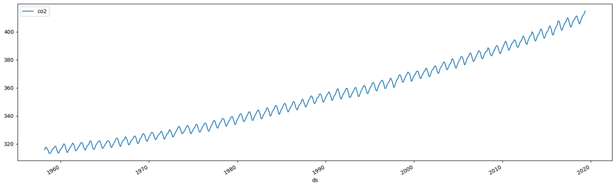

```python
y.plot(figsize=(20, 6))
```

#### Summary:

The provided data represents the monthly average atmospheric carbon dioxide (CO2) concentration measured from March 1958 to May 2019. The dataset contains 735 observations, with each row representing the CO2 concentration for a specific month.

The summary statistics for the CO2 data show that the average (mean) CO2 concentration is 354.21 parts per million (ppm), with a standard deviation of 27.92 ppm. The minimum CO2 concentration is 313.2 ppm, and the maximum is 414.83 ppm. The first quartile (25th percentile) of the CO2 concentration is 328.785 ppm, and the third quartile (75th percentile) is 376.515 ppm. The median (50th percentile) CO2 concentration is 351.34 ppm.

From the provided plot, it is evident that there is an overall upward trend in the CO2 concentration over time, which is a clear indication of increasing levels of atmospheric CO2. Moreover, there is a strong seasonality pattern in the data, which indicates that the CO2 concentration varies systematically with time of the year.

## Part 2. Seasonal ARIMA – need to use statsmodels in order to examine residuals

### 2.1 Determine the seasonal differencing order, use y_train. Include the following: plot of differenced data, ADF results, kpss results

```python
y_train, y_test = temporal_train_test_split(y)
```

```python
y_train.shape
```

```
(551, 1)
```

```python
y_test.shape
```

```
(184, 1)
```

```
seasonal differencing
```

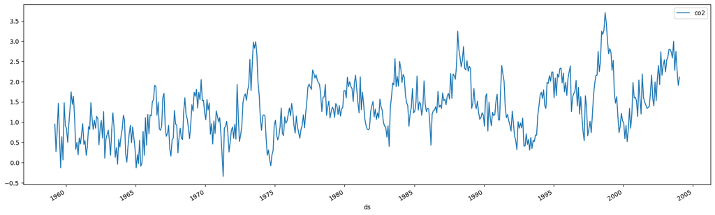

```python
trans_sdiff_data = (y_train-y_train.shift(12)).iloc[1:]
trans_sdiff_data.plot(figsize=(20, 6))
```

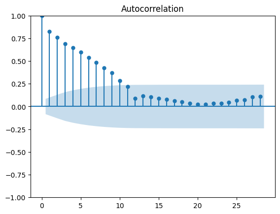

```python
plot_acf(trans_sdiff_data.dropna())
plt.show()
```

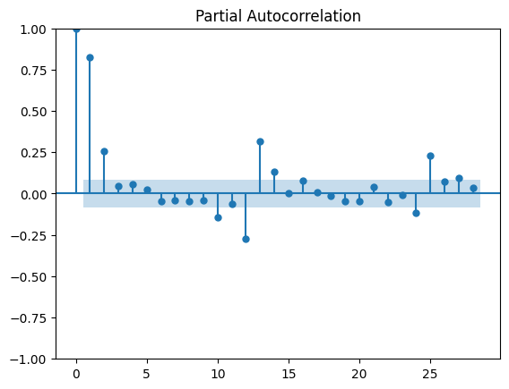

```python
plot_pacf(trans_sdiff_data.dropna())
plt.show()
```

```python
def adf_kpss_test(data):
    # ADF test
    result_adf = adfuller(data)
    print('ADF Test:')
    print(f'ADF Statistic: {round(result_adf[0],3)}')
    print(f'p-value: {round(result_adf[1],3)}')
    print(f'Critical Values: {result_adf[4]}')
    #print whether the data is stationary or not at 1% significance level
    if abs(result_adf[0]) > abs(result_adf[4]['1%']) and result_adf[1] < 0.05:
        print('We can reject the null hypothesis at 1% significance level that the data is NOT stationary. The data is likely stationary')
    else:
        print('We cannot reject the null hypothesis at 1% significance level that the data is NOT stationary. The data is likely NOT stationary')

    # KPSS test
    result_kpss = kpss(data, nlags='auto')
    print('\nKPSS Test:')
    print(f'KPSS Statistic: {round(result_kpss[0],3)}')
    print(f'p-value: {round(result_kpss[1],3)}')
    print(f'Critical Values: {result_kpss[3]}')
    #print whether the data is stationary or not at 1% significance level
    if abs(result_kpss[0]) > abs(result_kpss[3]['1%']) and result_kpss[1] < 0.05:
        print('We can reject the null hypothesis at 1% significance level that the data is stationary. The data is likely NOT stationary')
    else:
        print('We cannot reject the null hypothesis at 1% significance level that the data is stationary. The data is likely stationary')

    if result_adf[0] > result_adf[4]['1%'] and result_kpss[0] > result_kpss[3]['1%']:
        print('The ADF and KPSS tests are giving conflicting results.')
```

```python
adf_kpss_test(trans_sdiff_data.dropna())
```

```
ADF Test:
ADF Statistic: -3.993
p-value: 0.001
Critical Values: {'1%': -3.4428672600488066, '5%': -2.8670609714890403, '10%': -2.5697104770975057}
We can reject the null hypothesis at 1% significance level that the data is NOT stationary. The data is likely stationary

KPSS Test:
KPSS Statistic: 1.429
p-value: 0.01
Critical Values: {'10%': 0.347, '5%': 0.463, '2.5%': 0.574, '1%': 0.739}
We can reject the null hypothesis at 1% significance level that the data is stationary. The data is likely NOT stationary
```

Based on adf and kpss test, it apears that the seasonal differenced data is difference stationary. To achieve stationary, we need to difference the data next.

### 2.2 Determine the non-seasonal differencing order, use the seasonally differenced training time series. Include the following: plot of differenced data, ADF results, kpss results, ACF and PACF

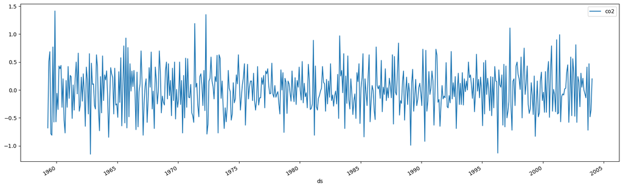

```python
trans_diff_data = (trans_sdiff_data-trans_sdiff_data.shift()).iloc[1:]
trans_diff_data.plot(figsize=(20, 6))
```

```python
adf_kpss_test(trans_diff_data.dropna())
```

```
ADF Test:
ADF Statistic: -8.793
p-value: 0.0
Critical Values: {'1%': -3.4429153652063986, '5%': -2.8670821452874007, '10%': -2.5697217608736187}
We can reject the null hypothesis at 1% significance level that the data is NOT stationary. The data is likely stationary

KPSS Test:
KPSS Statistic: 0.019
p-value: 0.1
Critical Values: {'10%': 0.347, '5%': 0.463, '2.5%': 0.574, '1%': 0.739}
We cannot reject the null hypothesis at 1% significance level that the data is stationary. The data is likely stationary
```

Now we can see our data after both seasonal and non-seasonal differencing is stationary.

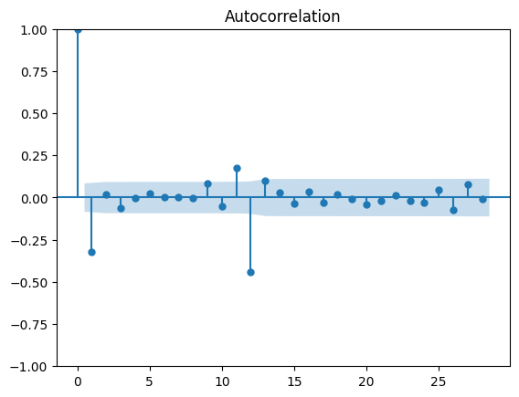

```python
plot_acf(trans_diff_data.dropna())
plt.show()
```

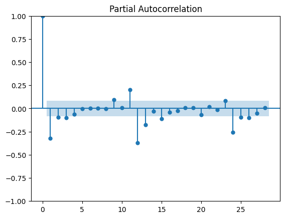

```python
plot_pacf(trans_diff_data.dropna())
plt.show()
```

### 2.3 Fit and predict a SARIMA model using your best estimate of the SARIMA(p,d,q)(P,D,Q)m order. Return the model summary

```python
model = SARIMAX(y_train, order=(3, 1, 0), seasonal_order=(2,1,0,12))
model_fit = model.fit()
```

[output not shown]

```
 This problem is unconstrained.
```

[output not shown]

```python
print(model_fit.summary())
```

```
                                     SARIMAX Results
==========================================================================================
Dep. Variable:                                co2   No. Observations:                  551
Model:             SARIMAX(3, 1, 0)x(2, 1, 0, 12)   Log Likelihood                -152.465
Date:                            Sat, 22 Apr 2023   AIC                            316.929
Time:                                    02:35:19   BIC                            342.657
Sample:                                         0   HQIC                           326.993
                                            - 551
Covariance Type:                              opg
==============================================================================
                 coef    std err          z      P>|z|      [0.025      0.975]
------------------------------------------------------------------------------
ar.L1         -0.3738      0.041     -9.188      0.000      -0.454      -0.294
ar.L2         -0.1755      0.044     -3.998      0.000      -0.262      -0.089
ar.L3         -0.1044      0.043     -2.448      0.014      -0.188      -0.021
ar.S.L12      -0.6196      0.041    -14.984      0.000      -0.701      -0.539
ar.S.L24      -0.3289      0.042     -7.856      0.000      -0.411      -0.247
sigma2         0.1021      0.006     16.066      0.000       0.090       0.115
===================================================================================
Ljung-Box (L1) (Q):                   0.04   Jarque-Bera (JB):                 0.51
Prob(Q):                              0.84   Prob(JB):                         0.77
Heteroskedasticity (H):               0.87   Skew:                             0.07
Prob(H) (two-sided):                  0.35   Kurtosis:                         2.93
===================================================================================

Warnings:
[1] Covariance matrix calculated using the outer product of gradients (complex-step).
```

```python
# Return AICc
print("AICc for order " + str(model.order) + str(model.seasonal_order) +": " +str(model_fit.aicc))
```

```
AICc for order (3, 1, 0)(2, 1, 0, 12): 317.0876908582133
```

### 2.4 Examine the residuals. Include the following: plot, histogram, ACF, Ljung Box results

```python
residuals = model_fit.resid[13:]
```

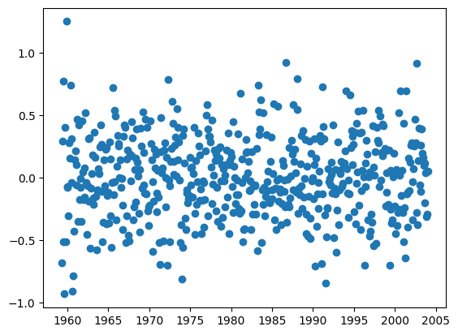

```python
plt.scatter(residuals.index, residuals)
```

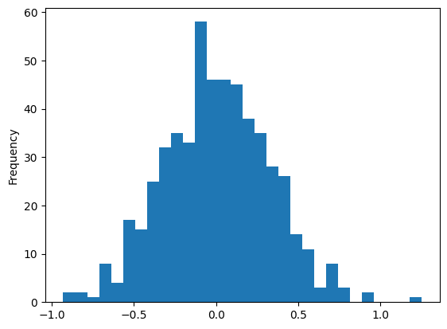

```python
residuals.plot(kind='hist', bins=30)
```

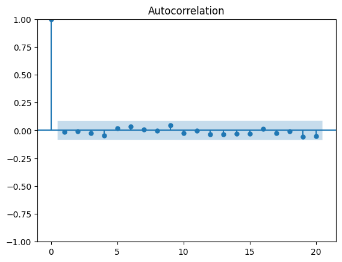

```python
plot_acf(residuals, lags=20)
plt.show()
```

```python
lb_test = acorr_ljungbox(residuals, lags=20)
lb_test
```

|  | lb_stat | lb_pvalue |
| --- | --- | --- |
| 1 | 0.083462 | 0.772660 |
| 2 | 0.118590 | 0.942428 |
| 3 | 0.377281 | 0.944895 |
| 4 | 1.664529 | 0.797150 |
| 5 | 1.860228 | 0.868127 |
| 6 | 2.542518 | 0.863679 |
| 7 | 2.578894 | 0.921040 |
| 8 | 2.589252 | 0.957439 |
| 9 | 3.662237 | 0.932205 |
| 10 | 3.955388 | 0.949337 |
| 11 | 3.955887 | 0.971190 |
| 12 | 4.643046 | 0.968852 |
| 13 | 5.357979 | 0.966444 |
| 14 | 5.911226 | 0.968680 |
| 15 | 6.451288 | 0.971130 |
| 16 | 6.530636 | 0.981284 |
| 17 | 6.898744 | 0.984823 |
| 18 | 6.957418 | 0.990481 |
| 19 | 8.812286 | 0.976469 |
| 20 | 10.271122 | 0.962985 |

Comment: From the plots, histogram we can conclude that the residuals are independently distributed with no significant autocorrelation, which suggests that the SARIMA model is a good fit for the time series data.

### 2.5 Predict the test set. Include the following: MAE, MSE, MAPE, sMAPE, MASE. Can use prebuilt functions or calculate by hand.

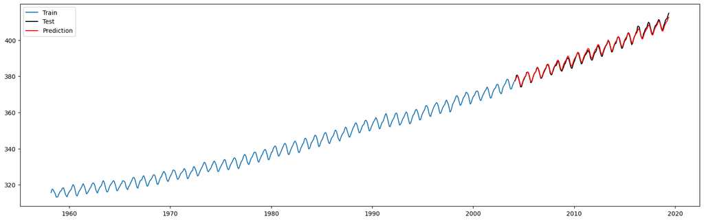

```python
y_pred=model_fit.forecast(steps = len(y_test))
plt.figure(figsize=(20, 6))
plt.plot(y_train.index, y_train.values, label='Train')
plt.plot(y_test.index, y_test.values, color='black', label='Test')

plt.plot(y_test.index, y_pred, color='red', label='Prediction')

plt.legend()
plt.show()
```

```python
# Calculate MAE and MSE
MAE = mean_absolute_error(y_test, y_pred)
MSE = mean_squared_error(y_test, y_pred)

# Calculate MAPE and sMAPE
MAPE = MeanAbsolutePercentageError(symmetric=False)(y_test, y_pred)
SMAPE = MeanAbsolutePercentageError(symmetric=True)(y_test, y_pred)

MASE = MeanAbsoluteScaledError()(y_test, y_pred, y_train=y_train)

# Print the results
print("MAE:", MAE)
print("MSE:", MSE)
print("MAPE:", MAPE)
print("sMAPE:", SMAPE)
print("MASE:", MASE)
```

```
MAE: 0.7179123632176928
MSE: 0.7104444872946616
MAPE: 0.001816940582567824
sMAPE: 0.001816518713020011
MASE: 0.6669681251494584
```

## Part 3. Auto ARIMA – need to use pmdarima in order to examine residuals

### 3.1 Fit using auto_arima(), you may need to provide the differencing orders.

```python
# fitting a stepwise model:
stepwise_fit = auto_arima(y_train, start_p=0, start_q=0, max_p=3, max_q=3, m=12,d = 1, max_d = 2, D = 1, max_D = 2,
                             seasonal=True,   trace=True, start_P=1, start_Q=1, max_P=3, max_Q=3,
                             error_action='ignore',  # don't want to know if an order does not work
                             suppress_warnings=True,  # don't want convergence warnings
                             stepwise=True)  # set to stepwise
```

```
Performing stepwise search to minimize aic
 ARIMA(0,1,0)(1,1,1)[12]             : AIC=inf, Time=0.39 sec
 ARIMA(0,1,0)(0,1,0)[12]             : AIC=555.695, Time=0.03 sec
 ARIMA(1,1,0)(1,1,0)[12]             : AIC=378.350, Time=0.09 sec
 ARIMA(0,1,1)(0,1,1)[12]             : AIC=234.067, Time=0.56 sec
 ARIMA(0,1,1)(0,1,0)[12]             : AIC=489.714, Time=0.03 sec
 ARIMA(0,1,1)(1,1,1)[12]             : AIC=235.773, Time=0.46 sec
 ARIMA(0,1,1)(0,1,2)[12]             : AIC=235.743, Time=1.78 sec
 ARIMA(0,1,1)(1,1,0)[12]             : AIC=368.160, Time=0.11 sec
 ARIMA(0,1,1)(1,1,2)[12]             : AIC=237.444, Time=3.74 sec
 ARIMA(0,1,0)(0,1,1)[12]             : AIC=inf, Time=0.44 sec
 ARIMA(1,1,1)(0,1,1)[12]             : AIC=234.554, Time=0.76 sec
 ARIMA(0,1,2)(0,1,1)[12]             : AIC=234.986, Time=0.50 sec
 ARIMA(1,1,0)(0,1,1)[12]             : AIC=242.703, Time=0.42 sec
 ARIMA(1,1,2)(0,1,1)[12]             : AIC=235.889, Time=0.91 sec
 ARIMA(0,1,1)(0,1,1)[12] intercept   : AIC=233.480, Time=0.67 sec
 ARIMA(0,1,1)(0,1,0)[12] intercept   : AIC=491.655, Time=0.07 sec
 ARIMA(0,1,1)(1,1,1)[12] intercept   : AIC=235.153, Time=1.05 sec
 ARIMA(0,1,1)(0,1,2)[12] intercept   : AIC=235.120, Time=2.53 sec
 ARIMA(0,1,1)(1,1,0)[12] intercept   : AIC=370.008, Time=0.31 sec
 ARIMA(0,1,1)(1,1,2)[12] intercept   : AIC=236.826, Time=3.10 sec
 ARIMA(0,1,0)(0,1,1)[12] intercept   : AIC=inf, Time=0.72 sec
 ARIMA(1,1,1)(0,1,1)[12] intercept   : AIC=233.335, Time=0.95 sec
 ARIMA(1,1,1)(0,1,0)[12] intercept   : AIC=493.034, Time=0.12 sec
 ARIMA(1,1,1)(1,1,1)[12] intercept   : AIC=235.011, Time=1.23 sec
 ARIMA(1,1,1)(0,1,2)[12] intercept   : AIC=234.977, Time=3.83 sec
 ARIMA(1,1,1)(1,1,0)[12] intercept   : AIC=371.326, Time=0.50 sec
 ARIMA(1,1,1)(1,1,2)[12] intercept   : AIC=236.623, Time=4.94 sec
 ARIMA(1,1,0)(0,1,1)[12] intercept   : AIC=242.736, Time=0.58 sec
 ARIMA(2,1,1)(0,1,1)[12] intercept   : AIC=inf, Time=1.29 sec
 ARIMA(1,1,2)(0,1,1)[12] intercept   : AIC=234.146, Time=1.48 sec
 ARIMA(0,1,2)(0,1,1)[12] intercept   : AIC=234.050, Time=0.99 sec
 ARIMA(2,1,0)(0,1,1)[12] intercept   : AIC=239.236, Time=0.74 sec
 ARIMA(2,1,2)(0,1,1)[12] intercept   : AIC=235.552, Time=1.28 sec

Best model:  ARIMA(1,1,1)(0,1,1)[12] intercept
Total fit time: 36.593 seconds
```

### 3.2 Return the model summary

```python
print(stepwise_fit.summary())
```

```
                                     SARIMAX Results
==========================================================================================
Dep. Variable:                                  y   No. Observations:                  551
Model:             SARIMAX(1, 1, 1)x(0, 1, 1, 12)   Log Likelihood                -111.667
Date:                            Sat, 22 Apr 2023   AIC                            233.335
Time:                                    02:36:08   BIC                            254.774
Sample:                                         0   HQIC                           241.721
                                            - 551
Covariance Type:                              opg
==============================================================================
                 coef    std err          z      P>|z|      [0.025      0.975]
------------------------------------------------------------------------------
intercept      0.0017      0.001      1.784      0.074      -0.000       0.004
ar.L1          0.2042      0.111      1.845      0.065      -0.013       0.421
ma.L1         -0.5415      0.099     -5.471      0.000      -0.736      -0.348
ma.S.L12      -0.8647      0.025    -34.890      0.000      -0.913      -0.816
sigma2         0.0860      0.005     16.185      0.000       0.076       0.096
===================================================================================
Ljung-Box (L1) (Q):                   0.04   Jarque-Bera (JB):                 0.25
Prob(Q):                              0.83   Prob(JB):                         0.88
Heteroskedasticity (H):               0.83   Skew:                            -0.05
Prob(H) (two-sided):                  0.22   Kurtosis:                         2.96
===================================================================================

Warnings:
[1] Covariance matrix calculated using the outer product of gradients (complex-step).
```

```python
# Return AICc
print("AICc for order " + str(stepwise_fit.order) + str(stepwise_fit.seasonal_order) +": " +str(stepwise_fit.aicc()))
```

```
AICc for order (1, 1, 1)(0, 1, 1, 12): 233.44486517384632
```

### 3.3 Examine the residuals. Include the following: plot, histogram, ACF, Ljung Box results

```python
residuals = stepwise_fit.resid()[13:]
```

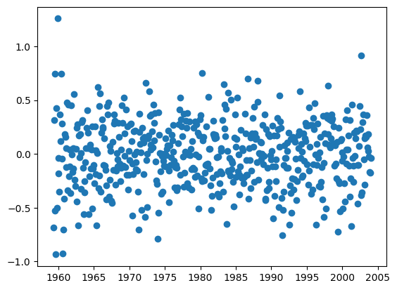

```python
plt.scatter(residuals.index, residuals)
```

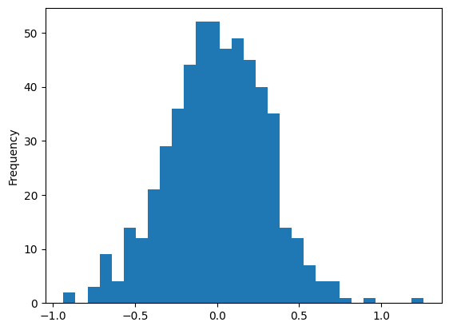

```python
residuals.plot(kind='hist', bins=30)
```

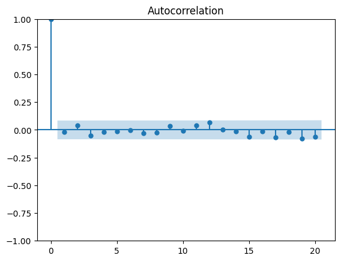

```python
plot_acf(residuals, lags=20)
plt.show()
```

```python
lb_test = acorr_ljungbox(residuals, lags=20)
lb_test
```

|  | lb_stat | lb_pvalue |
| --- | --- | --- |
| 1 | 0.177376 | 0.673638 |
| 2 | 0.972932 | 0.614795 |
| 3 | 2.400244 | 0.493589 |
| 4 | 2.623614 | 0.622646 |
| 5 | 2.698204 | 0.746393 |
| 6 | 2.712516 | 0.843967 |
| 7 | 3.185630 | 0.867315 |
| 8 | 3.491767 | 0.899828 |
| 9 | 4.231736 | 0.895509 |
| 10 | 4.281003 | 0.933781 |
| 11 | 5.075622 | 0.927449 |
| 12 | 7.437156 | 0.827425 |
| 13 | 7.437456 | 0.878224 |
| 14 | 7.554600 | 0.911217 |
| 15 | 9.753543 | 0.834950 |
| 16 | 9.831483 | 0.875279 |
| 17 | 12.446644 | 0.772370 |
| 18 | 12.692757 | 0.809492 |
| 19 | 16.271932 | 0.639064 |
| 20 | 18.360552 | 0.563670 |

Comment: From the plots, histogram we can conclude that the residuals are independently distributed with no significant autocorrelation, which suggests that the SARIMA model is a good fit for the time series data.

### 3.4 Predict the test set. Include the following: MAE, MSE, MAPE, sMAPE, MASE. Can use prebuilt functions or calculate by hand.

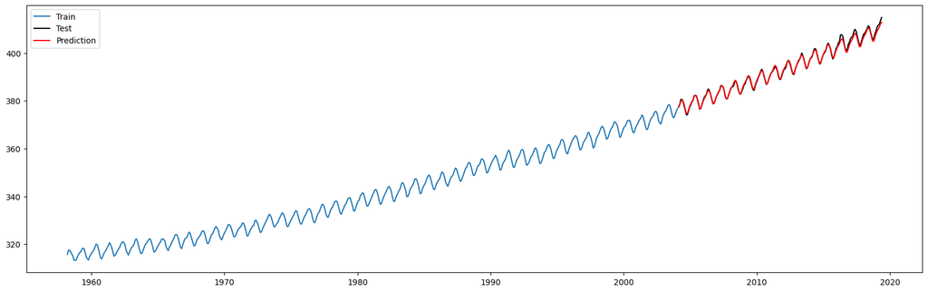

```python
y_pred = stepwise_fit.predict(n_periods=len(y_test))
plt.figure(figsize=(20, 6))
plt.plot(y_train.index, y_train.values, label='Train')
plt.plot(y_test.index, y_test.values, color='black', label='Test')

plt.plot(y_test.index, y_pred, color='red', label='Prediction')

plt.legend()
plt.show()
```

```python
# Calculate MAE and MSE
MAE = mean_absolute_error(y_test, y_pred)
MSE = mean_squared_error(y_test, y_pred)

# Calculate MAPE and sMAPE
MAPE = MeanAbsolutePercentageError(symmetric=False)(y_test, y_pred)
SMAPE = MeanAbsolutePercentageError(symmetric=True)(y_test, y_pred)

MASE = MeanAbsoluteScaledError()(y_test, y_pred, y_train=y_train)

# Print the results
print("MAE:", MAE)
print("MSE:", MSE)
print("MAPE:", MAPE)
print("sMAPE:", SMAPE)
print("MASE:", MASE)
```

```
MAE: 0.4912185608334355
MSE: 0.4378804061810001
MAPE: 0.0012332453542239269
sMAPE: 0.001234084131698256
MASE: 0.45636088657014134
```

### 3.5 Summarize the difference between your SARIMA and the Auto Arima models. Compare order, performance on training data, performance on test data. Which model would you go forward with?

I would go with auto arima.

## Part 4. Recursive method with best model

### 4.A Use/modify the rolling fit class to fit and predict with the best model from above. Adjust train size from the sample in RollingFit_for_Assignment4.ipynb. This probably works best w sktime implementation.

```python
y = pd.read_csv('hw4_data.csv', index_col=0)
y.index = pd.core.indexes.period.PeriodIndex(y.index, freq='m')
```

```python
y
```

| ds | co2 |
| --- | --- |
| 1958-03 | 315.700 |
| 1958-04 | 317.450 |
| 1958-05 | 317.510 |
| 1958-06 | 316.685 |
| 1958-07 | 315.860 |
| ... | ... |
| 2019-01 | 410.920 |
| 2019-02 | 411.660 |
| 2019-03 | 412.000 |
| 2019-04 | 413.510 |
| 2019-05 | 414.830 |

735 rows × 1 columns

```python
class RollingFit:
    def __init__(self, y, train_size=50, model=None):

        self.y = y
        self.model = model

        self.train_y, self.test_y = temporal_train_test_split(y, train_size=train_size)
        self._test_y = self.test_y
        self.ypred_ = self.train_y
        self.fit()

    def fit(self):
        N = len( self.test_y )
        for i in range(0, N):

            self.fit_model()
            ypred = self.predict_one()
            self.add_to_predictions( ypred )
            self.move_one_test_to_train()
            self.drop_one_from_test()


    def fit_model(self):
        y = self.train_y
        self.model.fit( y )

    def predict_one(self):
        ypred = self.model.predict(1)
        return ypred

    def add_to_predictions(self, ypred):
        self.ypred_ = pd.concat([self.ypred_, ypred])


    def move_one_test_to_train(self):
        series_to_add = pd.Series(
            self.test_y[0],
            index = [ self.test_y.index[0] ]
        )
        self.train_y = pd.concat( [self.train_y, series_to_add ])

    def drop_one_from_test(self):
        self.test_y = self.test_y[1:]
```

```python
rolling_fit_model = RollingFit(y['co2'], model=ARIMA((1,1,1), seasonal_order=(0,1,1,12) ), train_size=50)
```

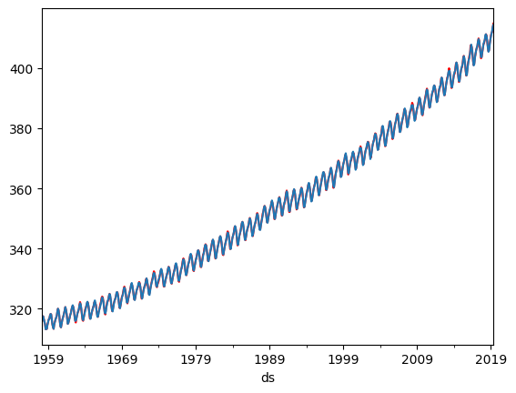

```python
rolling_fit_model.y.plot(color='red')
rolling_fit_model.ypred_.plot()
plt.show()
```

### 4.C Include the following: MAE, MSE, MAPE, sMAPE, MASE. Can use prebuilt functions or calculate by hand.

```python
# Calculate MAE and MSE
MAE = mean_absolute_error(rolling_fit_model._test_y, rolling_fit_model.ypred_[50:])
MSE = mean_squared_error(rolling_fit_model._test_y, rolling_fit_model.ypred_[50:])

# Calculate MAPE and sMAPE
MAPE = MeanAbsolutePercentageError(symmetric=False)(rolling_fit_model._test_y, rolling_fit_model.ypred_[50:])
SMAPE = MeanAbsolutePercentageError(symmetric=True)(rolling_fit_model._test_y, rolling_fit_model.ypred_[50:])

MASE = MeanAbsoluteScaledError()(rolling_fit_model._test_y, rolling_fit_model.ypred_[50:], y_train=y_train)

# Print the results
print("MAE:", MAE)
print("MSE:", MSE)
print("MAPE:", MAPE)
print("sMAPE:", SMAPE)
print("MASE:", MASE)
```

```
MAE: 0.24732636120043583
MSE: 0.09793430154494932
MAPE: 0.0006938257652669417
sMAPE: 0.000693849195442306
MASE: 0.2297756772018034
```

### 4.D Summarize the difference between your Recursive forecasts and your h-step ahead forecasts from SARIMA and Auto ARIMA. Explain the methodologies and the reason that you get different results. What are the advantages and disadvantages of the recursive method.

The rolling fit model outperforms SARIMAX and Auto ARIMA in terms of all metrics, including MAE, MSE, MAPE, sMAPE, and MASE. This suggests that the rolling fit model provides more accurate forecasts than SARIMAX and Auto ARIMA for this particular dataset.

The recursive method used in the rolling fit model involves re-fitting the model and making one-step-ahead forecasts for each new data point. In contrast, the h-step ahead forecasts from SARIMAX and Auto ARIMA involve estimating the parameters of the model once and then forecasting h steps ahead using those fixed parameters.

The advantage of the recursive method is that it adapts to changes in the data over time and can potentially provide more accurate forecasts. However, it requires re-fitting the model for each new data point, which can be computationally expensive and may not be feasible for large datasets. In contrast, the h-step ahead forecasts from SARIMAX and Auto ARIMA can be more efficient computationally and may be more suitable for large datasets, but may not be as accurate as the recursive method for datasets with non-stationary or changing dynamics over time.